# Investigation of the weather events with the highest impact in health and economy across the United States

## Synopsis

Storms and other severe weather events can cause both public health and economic problems for communities and municipalities. Many severe events can result in fatalities, injuries, and property damage.

The dataset used for the study originate from the U.S. National Oceanic and Atmospheric Administration’s (NOAA) storm database. This database tracks characteristics of major storms and weather events in the United States, including when and where they occur, as well as estimates of any fatalities, injuries, and property damage.

The purpose of the analysis is to conclude which of the event types pose the higher threat for society, across the United States, in terms of a) population health and b) economic consequences.

## Data Information

The data for this assignment come in the form of a comma-separated-value file compressed via the bzip2 algorithm to reduce its size. The file from the course web site:

- [Storm Data](https://d396qusza40orc.cloudfront.net/repdata%2Fdata%2FStormData.csv.bz2) [47Mb]

There is also some documentation of the database available where further information can be found such as how some of the variables are constructed/defined.

- [National Weather Service Storm Data Documentation](https://d396qusza40orc.cloudfront.net/repdata%2Fpeer2_doc%2Fpd01016005curr.pdf)
- [National Climatic Data Center Storm Events FAQ](https://d396qusza40orc.cloudfront.net/repdata%2Fpeer2_doc%2FNCDC%20Storm%20Events-FAQ%20Page.pdf)

The events in the database start in the year 1950 and end in November 2011. In the earlier years of the database there are generally fewer events recorded, most likely due to a lack of good records. More recent years should be considered more complete.

## Data Processing

The first step of processing is to load the data. In order to avoid loading data that are not used, the first 6 rows of the file are read and information is extracted to read only the desired columns (variables). In accordance with the documentation and the extracted variables, the needed variables are EVTYPE (event type), FATALITIES, INJURIES, PROPDMG (Property Damage), PROPDMGEXP (Property Damage Exponent), CROPDMG (Crop Damage) and CROPDMGEXP (Crop Damage Exponent).

```r
url <- "https://d396qusza40orc.cloudfront.net/repdata%2Fdata%2FStormData.csv.bz2"
file_bz2 <- "repdata_data_StormData.csv.bz2"

if (!file.exists(file_bz2))
     download.file(url, file_bz2)

DT_head <- read.csv(file_bz2, nrows = 6)

names(DT_head)
```

```
##  [1] "STATE__"    "BGN_DATE"   "BGN_TIME"   "TIME_ZONE"  "COUNTY"
##  [6] "COUNTYNAME" "STATE"      "EVTYPE"     "BGN_RANGE"  "BGN_AZI"
## [11] "BGN_LOCATI" "END_DATE"   "END_TIME"   "COUNTY_END" "COUNTYENDN"
## [16] "END_RANGE"  "END_AZI"    "END_LOCATI" "LENGTH"     "WIDTH"
## [21] "F"          "MAG"        "FATALITIES" "INJURIES"   "PROPDMG"
## [26] "PROPDMGEXP" "CROPDMG"    "CROPDMGEXP" "WFO"        "STATEOFFIC"
## [31] "ZONENAMES"  "LATITUDE"   "LONGITUDE"  "LATITUDE_E" "LONGITUDE_"
## [36] "REMARKS"    "REFNUM"
```

```r
columns_to_read <- rep("NULL", ncol(DT_head))

columns_to_read[c(8, 23:28)] <- c("factor", rep("numeric", 2),
                                  rep(c("numeric", "factor"), 2))

DT <- read.csv(file_bz2, colClasses = columns_to_read)
```

From the summary of the dataset and the schema of the data frame some initial remarks about the variables can be made:

```r
summary(DT)
```

```
##                EVTYPE         FATALITIES     INJURIES         PROPDMG
##  HAIL             :288661   Min.   :  0   Min.   :   0.0   Min.   :   0
##  TSTM WIND        :219940   1st Qu.:  0   1st Qu.:   0.0   1st Qu.:   0
##  THUNDERSTORM WIND: 82563   Median :  0   Median :   0.0   Median :   0
##  TORNADO          : 60652   Mean   :  0   Mean   :   0.2   Mean   :  12
##  FLASH FLOOD      : 54277   3rd Qu.:  0   3rd Qu.:   0.0   3rd Qu.:   0
##  FLOOD            : 25326   Max.   :583   Max.   :1700.0   Max.   :5000
##  (Other)          :170878
##    PROPDMGEXP        CROPDMG        CROPDMGEXP
##         :465934   Min.   :  0.0          :618413
##  K      :424665   1st Qu.:  0.0   K      :281832
##  M      : 11330   Median :  0.0   M      :  1994
##  0      :   216   Mean   :  1.5   k      :    21
##  B      :    40   3rd Qu.:  0.0   0      :    19
##  5      :    28   Max.   :990.0   B      :     9
##  (Other):    84                   (Other):     9
```

```r
str(DT)
```

```
## 'data.frame':    902297 obs. of  7 variables:
##  $ EVTYPE    : Factor w/ 985 levels "   HIGH SURF ADVISORY",..: 834 834 834 834 834 834 834 834 834 834 ...
##  $ FATALITIES: num  0 0 0 0 0 0 0 0 1 0 ...
##  $ INJURIES  : num  15 0 2 2 2 6 1 0 14 0 ...
##  $ PROPDMG   : num  25 2.5 25 2.5 2.5 2.5 2.5 2.5 25 25 ...
##  $ PROPDMGEXP: Factor w/ 19 levels "","-","?","+",..: 17 17 17 17 17 17 17 17 17 17 ...
##  $ CROPDMG   : num  0 0 0 0 0 0 0 0 0 0 ...
##  $ CROPDMGEXP: Factor w/ 9 levels "","?","0","2",..: 1 1 1 1 1 1 1 1 1 1 ...
```

```r
levels(DT$PROPDMGEXP)
```

```
##  [1] ""  "-" "?" "+" "0" "1" "2" "3" "4" "5" "6" "7" "8" "B" "h" "H" "K"
## [18] "m" "M"
```

```r
levels(DT$CROPDMGEXP)
```

```
## [1] ""  "?" "0" "2" "B" "k" "K" "m" "M"
```

The number of different event types is 985 and the variety of the names used is large.

The summaries of FATALITIES and INJURIES show that a high percentage of the values are zero (more than 99% and 98% respectively) and that they have a small amount of high values (maximum values are 583 and 1700 respectively).

According to the documentation the values of PROPDMGEXP and CROPDMGEXP shoud have values “K”, “M” and “B” corresponding to thousands, millions and billions respectively. But looking at the summary some different values are also found. The “k”, “m” and “b” can be due to typing mistakes. The “h” and “H” shown below can also be interpreted as hundreds as their contribution to the results is limited. The other symbols will be removed from the analysis.

In addition the letters are replaced with the corresponding numbers (1000, 1000000, 1000000000) to calculate total damages (property + corps damage) in dollars.

```r
levels(DT$PROPDMGEXP) <- c(rep("X", 13), "B", "H", "H", "K", "M", "M")
levels(DT$CROPDMGEXP) <- c(rep("X", 4), "B", "K", "K", "M", "M")

levels(DT$PROPDMGEXP) <- c("0", "1000000000", "100", "1000", "1000000")
levels(DT$CROPDMGEXP) <- c("0", "1000000000", "1000", "1000000")

DT$PROPDMG <- DT$PROPDMG*as.numeric(as.character(DT$PROPDMGEXP))
DT$CROPDMG <- DT$CROPDMG*as.numeric(as.character(DT$CROPDMGEXP))
DT$DMG <- round((DT$PROPDMG + DT$CROPDMG)/1000000000, digits = 2)
DT$PROPDMG <- NULL
DT$CROPDMG <- NULL
DT$PROPDMGEXP <- NULL
DT$CROPDMGEXP <- NULL

names(DT) <- c("event.type", "fatalities", "injuries",
               "damage")
```

An exploration of the data is performed to estimate the number of event types that are more dominant in the dataset. This is accomplished by ranking the data according to the frequency of appearance of the event types, choosing a set of the highest frequencies and taking into consideration the percentage of fatalities, injuries and damages that correspond to the selected set.

```r
DTag_sum <- aggregate(. ~ event.type, data = DT, sum)

event_count <- tapply(DT$event.type, DT$event.type, length)

DTag_sum$event_count <- event_count

DTag_sum_order_cum <- DTag_sum[order(DTag_sum$event_count, decreasing = TRUE),]

DTag_sum_order_cum[, 2:5] <- sapply(c(2:5),
     function(i) cumsum(DTag_sum_order_cum[, i])/
          sum(DTag_sum_order_cum[, i])*100)

DTag_sum_order_cum$event.num <- seq(1,
          length(DTag_sum_order_cum$event.type))

DTag_sum_order_cum[c(20, 50, 100, 150, 200), ]
```

```
##              event.type fatalities injuries damage event_count event.num
## 957            WILDFIRE      63.08    86.33  55.44       96.03        20
## 670         STORM SURGE      93.88    97.45  74.24       99.13        50
## 503 MIXED PRECIPITATION      97.09    99.05  97.18       99.68       100
## 44         BLOWING SNOW      98.43    99.50  97.57       99.79       150
## 679        Strong Winds      98.72    99.57  98.55       99.84       200
```

From the results it is obvious that, by taking into account the 200 event types with the highest frequency, the percentage of the variables of interest (fatalities, injuries, damage) is more than 98.5%.

These 200 event types are used to define the rules to correct typographic mistakes during data entry and group event types that appear to belong in the same category. The information about the dataset (variables, documentation) and general severe weather events categories (http://en.wikipedia.org/wiki/List_of_severe_weather_phenomena) are used to clean weather events nomenclature.

```r
event_types <- DT$event.type
event_types <- tolower(event_types)

event_types[grepl("flood|floood", event_types)] <- "flood"
event_types[grepl("freeze|cold|chill|freez|frost|cool|low|winter weather|wintry", event_types)] <- "cold"
event_types[grepl("heat|warmth|warm|record", event_types)] <- "heat"
event_types[grepl("snow", event_types)] <- "snow"
event_types[grepl("hail", event_types)] <- "hail"
event_types[grepl("wind", event_types)] <- "wind"
event_types[grepl("storm", event_types)] <- "storm"
event_types[grepl("hurricane|typhoon", event_types)] <- "hurricane"
event_types[grepl("ice|glaze|icy", event_types)] <- "ice"
event_types[grepl("rain|shower", event_types)] <- "rain"
event_types[grepl("tornado|waterspout", event_types)] <- "tornado"
event_types[grepl("storm", event_types)] <- "storm"
event_types[grepl("thunderstorm", event_types)] <- "thunderstorm"
event_types[grepl("fog", event_types)] <- "fog"
event_types[grepl("tsunami|rip|surf|seas|wave|marine accident|marine mishap", event_types)] <- "high seas"
event_types[grepl("funnel", event_types)] <- "funnel clouds"
event_types[grepl("tide", event_types)] <- "tide"
event_types[grepl("drought|dry", event_types)] <- "drought"
event_types[grepl("fire", event_types)] <- "fire"
event_types[grepl("blizzard", event_types)] <- "blizzard"
event_types[grepl("avalanche|avalanche", event_types)] <- "avalanche"
event_types[grepl("wet", event_types)] <- "wet weather"
event_types[grepl("lighting|lightning.|ligntning", event_types)] <- "lighting"
event_types[grepl("precipitation|mixed precip", event_types)] <- "mixed precipitation"

DT$event.type <- event_types
```

Aggregated data for fatalities, injuries and total damages in relation to the different event types are created for plotting purposes.

```r
DTag_sum <- aggregate(. ~ event.type, data = DT, sum)

DTag_mean <- aggregate(. ~ event.type, data = DT, mean)

event_count <- tapply(DT$event.type, DT$event.type, length)
```

The dominant event types are recalculated for event count, fatalities, injuries and damages.

```r
DTag_sum$event_count <- event_count

DTag_sum_order_cum <- DTag_sum[order(DTag_sum$event_count, decreasing = TRUE),]

DTag_sum_order_cum[, 2:5] <- sapply(c(2:5),
     function(i) cumsum(DTag_sum_order_cum[, i])/
          sum(DTag_sum_order_cum[, i])*100)

DTag_sum_order_cum$event.num <- seq(1,
     length(DTag_sum_order_cum$event.type))

DTag_sum_order_cum[c(10, 20, 30, 40, 50), ]
```

```
##        event.type fatalities injuries damage event_count event.num
## 25  funnel clouds      68.85    88.75  73.83       97.53        10
## 41      hurricane      99.68    99.65  99.97       99.88        20
## 173   wet weather      99.85   100.00 100.00       99.97        30
## 57      mud slide      99.89   100.00 100.00       99.98        40
## 73   saharan dust      99.97   100.00 100.00       99.98        50
```

## Results

### 1. Across the United States, which types of events are most harmful with respect to population health?

In order to evaluate the impact of severe weather events to population health, the 10 most severe event types (highest total number of injuries) are extracted, the table is printed and a plot is presented. Tornadoes have the highest number of injuries and fatalities. Less severe but with high impact are also wind, heat and floods.

Similar results for average injuries/fatalities (injuries/fatalities per event) are presented and further results about public health impact can be illustrated. Hurricanes and heat seem to be the most severe.

```r
num_events_plot <- 10

DTag_sum[order(DTag_sum$injuries,
     decreasing = TRUE)[1:num_events_plot], 1:3]
```

```
##     event.type fatalities injuries
## 151    tornado       5639    91436
## 174       wind       1178    11314
## 29        heat       3178     9243
## 23       flood       1525     8604
## 52   lightning        816     5230
## 83       storm        422     4236
## 22        fire         90     1608
## 28        hail         45     1467
## 41   hurricane        133     1333
## 81        snow        151     1152
```

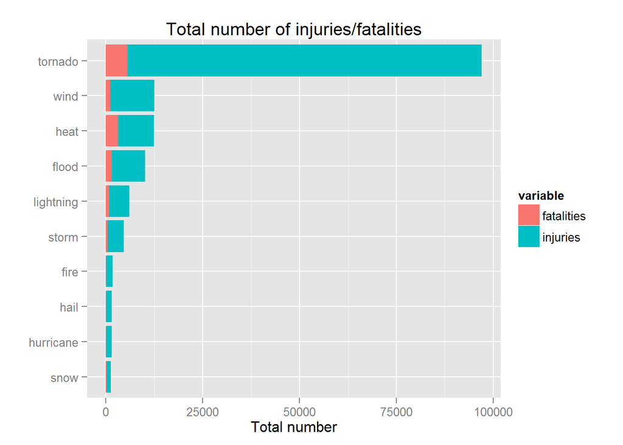

```r
DTag_sum10_melted <- melt(DTag_sum[order(DTag_sum$injuries,
     decreasing = TRUE)[1:num_events_plot], 1:3],
     id.vars = "event.type", value.name = "count")

ggplot(DTag_sum10_melted,
       aes(x = event.type, y = count, fill = variable)) +
       geom_bar(stat = "identity") +
       coord_flip() +
       ylab("Total number") +
       xlab("") +
       ggtitle("Total number of injuries/fatalities") +
       scale_x_discrete(limit = DTag_sum10_melted[num_events_plot:1, 1])
```

**In the figure above, the total number of injuries and fatalities across the United States for the top 10 weather events with the highest total injuries is presented.**

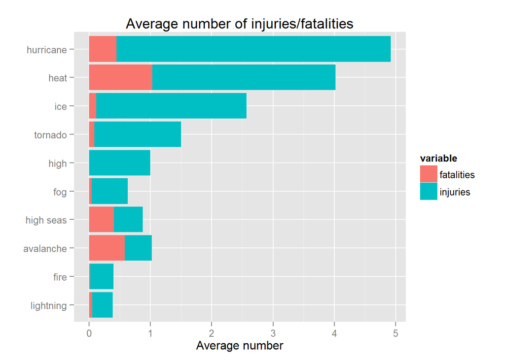

```r
DTag_mean10_melted <- melt(DTag_mean[order(DTag_mean$injuries,
     decreasing = TRUE)[1:num_events_plot], 1:3],
     id.vars = "event.type", value.name = "count")

ggplot(DTag_mean10_melted,
       aes(x = event.type, y = count, fill = variable)) +
       geom_bar(stat = "identity") +
       coord_flip() +
       ylab("Average number") +
       xlab("") +
       ggtitle("Average number of injuries/fatalities") +
       scale_x_discrete(limit = DTag_mean10_melted[num_events_plot:1, 1])
```

**In the figure above, the average number of injuries and fatalities across the United States for the top 10 weather events with the highest average injuries is presented.**

### 2. Across the United States, which types of events have the greatest economic consequences?

The impact in economy of the various weather events is investigated. Floods and hurricanes appear to have the worst economical effects. The table and plot of the 10 weather event types with the highest damages are presented:

```r
num_events_plot <- 10

DTag_sum[order(DTag_sum$damage, decreasing = TRUE)[1:num_events_plot],
         c(1, 4)]
```

```
##     event.type damage
## 23       flood 173.54
## 41   hurricane  90.69
## 83       storm  72.46
## 151    tornado  43.68
## 28        hail  17.88
## 17     drought  14.90
## 174       wind  12.49
## 22        fire   8.56
## 67        rain   3.90
## 11        cold   3.56
```

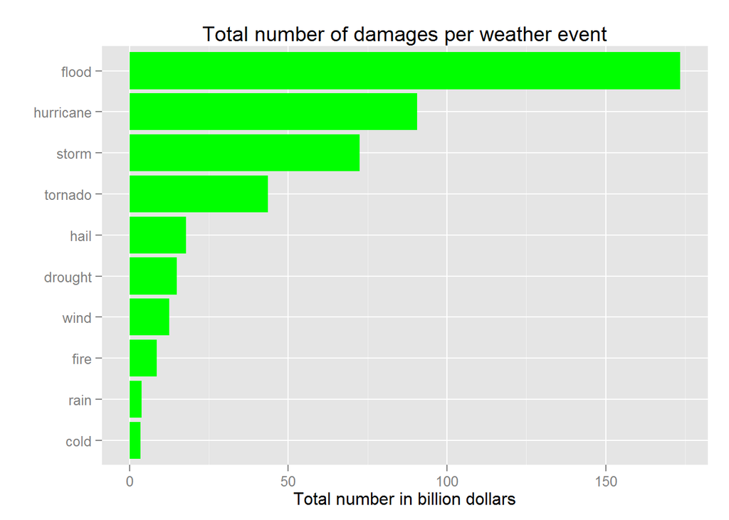

```r
DTag_dmg_sum10_melted <- melt(DTag_sum[order(DTag_sum$damage,
     decreasing = TRUE)[1:num_events_plot], c(1, 4)],
     id.vars = "event.type", value.name = "count")

ggplot(DTag_dmg_sum10_melted, aes(x = event.type, y = count)) +
          geom_bar(stat = "identity", fill = "green") +
          coord_flip() +
          ylab("Total number in billion dollars") +
          xlab("") +
          ggtitle("Total number of damages per weather event") +
          scale_x_discrete(limit = DTag_dmg_sum10_melted[num_events_plot:1, 1])
```

**In the figure above, the total number of damages per weather event, across the United States, for the top 10 weather events with the highest total damages is presented.**